# MP3

Tingwei Hu, Brendan Fox, Minho Heo, Christian Peterson

2023-03-14

# Introduction

The third Mini Project involves examining experimental methods for measuring the material and structural properties of biological tissue such as wood and intestine. Material properties are those that are inherent to the material itself and are independent of its size and shape. Structural properties, on the other hand, are related to the size and shape of the material. Topics of interest include the non-Hookean quality of biological materials and the respective anisotropic behaviors. In addition to the viscoelastic quality evident through differing forces of load. The three-point bending test will also be pivotal in understanding the natural response of a material and the resulting biomechanical characteristics that give it a unique quality. By understanding these properties, researchers can gain valuable insights into the behavior and performance of biological tissues, which may be useful in a variety of fields, including engineering and medicine.

# Materials and Methods

The wood bending experiment involves three-point bending of a piece of wood to measure its load and deformation properties. The wood is initially deflected a known distance, and then a cylinder is depressed against the wood at either a slow or fast speed to read the load data from the load cell system. An important factor to consider in this experiment is anisotropy, which refers to the variation in properties of a material along different axes. Wood is an anisotropic material, meaning that its properties can vary depending on the direction in which it is measured. Therefore, it is crucial to take measurements in different orientations to gain a comprehensive understanding of its properties. For procedure, see directions on the course website. No amendments were made to the procedure.

The pig intestine experiment involves measuring the stress-strain relationship of the intestine by cutting a small strip of the material and stretching it with a known force applied to one end. The stress created within the material causes it to elongate, and we can measure its deformation and derive its stress-strain relationship. The experiment also involves testing the intestine in both axial and circumferential directions to account for and examine anisotropy in the material. For procedure, see directions on the course website.

Load strain, unload strain (both normalized unit), load (in N), and area (in m<sup>2</sup>) were calculated from experimental data and manually entered into r for further processing analysis. We obtained the slope of the stress-strain curve in both conditions, which corresponds to the stiffness of the material in the elastic region according to $M=EI$, where $M$ is stiffness, $E$ is Young’s modulus, and $I$ is second moment area.

# Results

## Pig Stretched

We plotted stress v. strain for both the axial and circumferential stretching condition. The intestine stretched longitudinally (slope = 8.24x10<sup>4</sup>) was stiffer than stretcehd circumferentially (4.9x10<sup>3</sup>).

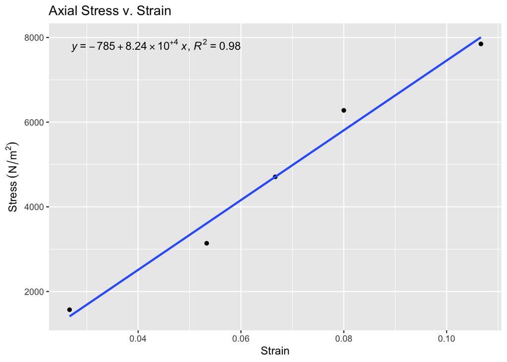

**Figure 1**: Stress v. strain curve of the longitudinal loading of the intestine. It portrays the increasing stress (addition of nuts weighing 3.2g) added onto the intestine and the resulting strain from it. The best line of fit has a slope of 8.24x10<sup>4</sup>, which represents the stiffness.

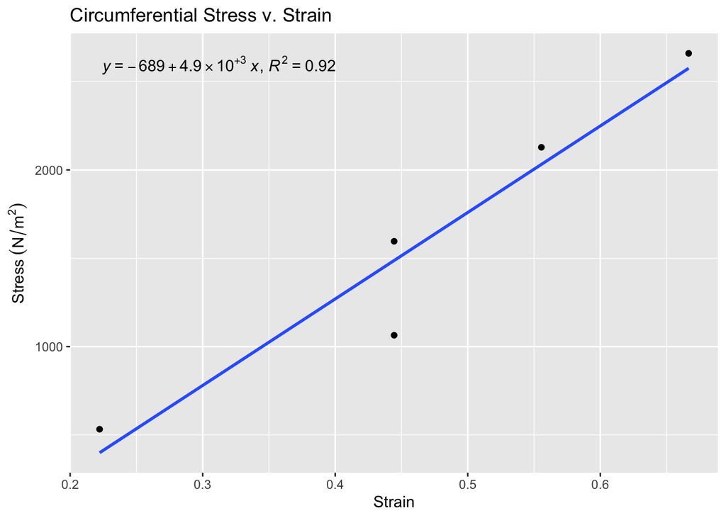

**Figure 2**: Stress v. strain curve of the circumferential loading of the intestine. The best line of fit has a slope of 4.9x10<sup>3</sup>, which representes the stiffness

## Twig Bent

We calculated fleural stiffness of provided wooden sticks with a semi-factorial experiment design. See Table 1 for all reported results. The stick bent in a dry & flipped condition (0.1680) had a much higher flexural stiffness than in the dry & flat (0.0550 and 0.0605 for fast and slow, respectively) condition (Figure 3).

```
##   dry.wet flat.flip slow.fast     force length deflection  flx.stiff
## 1     dry      flat      fast  5.770105  0.035     0.0015 0.05497627
## 2     dry      flat      slow  6.349395  0.035     0.0015 0.06049562
## 3     dry   flipped      slow 17.637222  0.035     0.0015 0.16804354
## 4     wet      flat      fast  3.168787  0.035     0.0015 0.03019150
## 5     wet      flat      slow  3.016830  0.035     0.0015 0.02874369
```

**Table 1:** Relevant data from all conditions used to calculate flexural stiffness (FS).

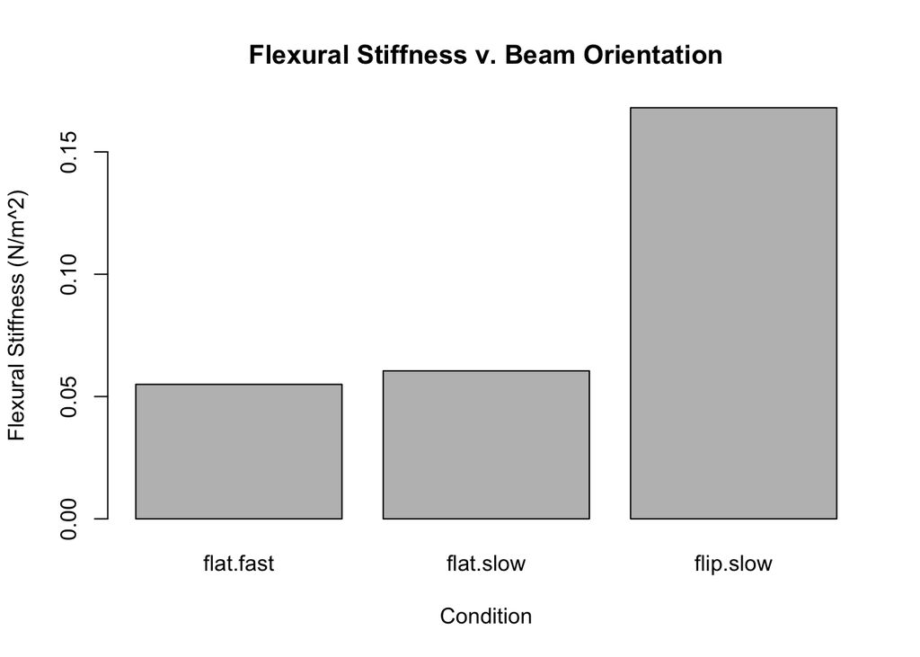

**Figure 3:** Flexural stiffness (*EI*) of different orientations of the dry wood beam. Flexural stiffness was calculated through the derivation of the equation: $d = (FL^3)/(3EI)$.

We calculated strain rate of the wood strip by obtaining the slope of data points loading and strain from the beginning to maximum absolute value from the experiment files in each relevant condition and characterized it as the strain rate (Table 2). Flexural stiffness was plotted against strain rate in each respective condition (Figure 4) and found that it was higher in the dry condition regardless of bending speed.

```
##   dry.wet slow.fast     slope  flx.stiff
## 1     dry      fast 139.83324 0.05497627
## 2     dry      slow  28.06529 0.06049562
## 3     wet      fast  84.24003 0.03019150
## 4     wet      slow  13.47904 0.02874369
```

**Table 2:** Slope of stress-strain curve and flexural stiffness for each wood condition.

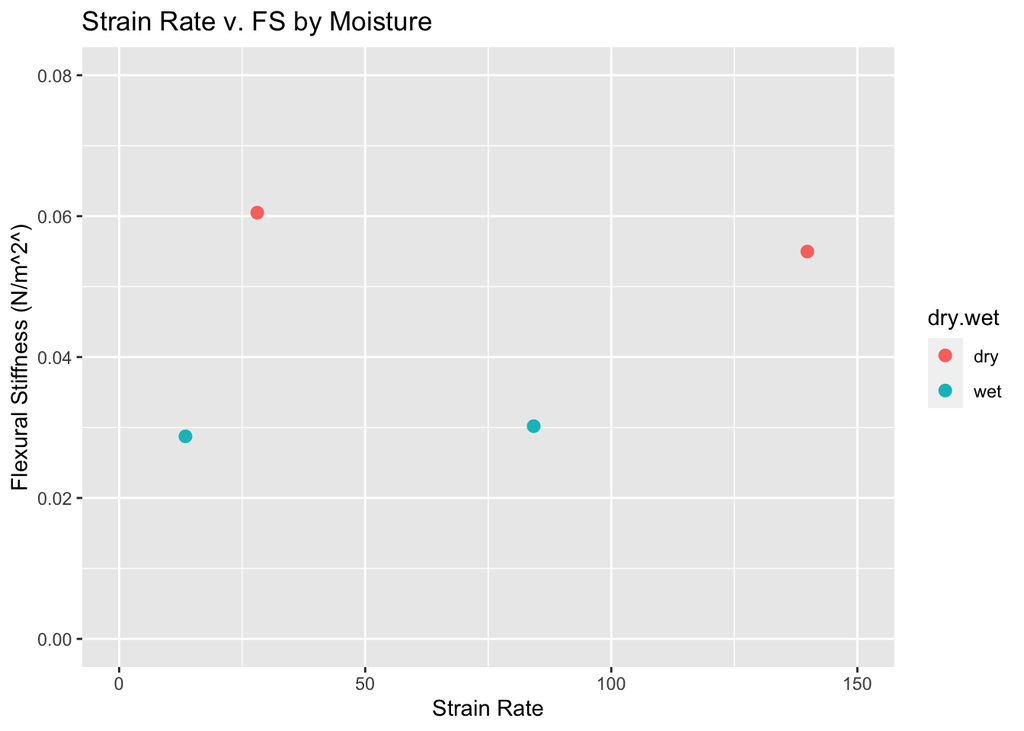

**Figure 4:** Flexural stiffness vs. the strain rate of the different beam experiments (flat orientations) on basis of their moistures and the speed of the cylinder depression (fast v. slow). The dry-fast and dry-slow trials had greater strain rate and FS than their respective wet-fast and wet-slow trials.

# Discussion

## Question 1

The stiffness of the intestine in axial loading (8.24x10<sup>4</sup> N/m<sup>2</sup>) is greater than that of circumferential loading (4.9x10<sup>3</sup> N/m<sup>2</sup>). In a stress-strain model, the slope of the curve is representative of the stiffness (Young’s modulus) - although this is under the assumption that the material acts as an ideal spring so that Hooke’s law is in effect and thus the slope is constant. However, in many biological materials this is not the case.

## Question 2

Anisotropy occurs in which stress and strain vary in the direction at which the stress is applied on the respective material. In the experiment testing the structural and material properties of the intestine, the resulting stress v. strain curve for axial and circumferential loaded experiments resulted in differing stiffness values. This indicates that the intestinal tube is anisotropic because the intestine is stiffer in the axial/longitudinal direction, which biomechanically makes sense in the context of peristalsis. In the instance that the intestinal tube was not anisotropic, the stiffness of the two stress v. strain curves would be the same because that would indicate that regardless of the direction at which stress is applied to the intestine, it undergoes the same strain.

## Question 3

The intestine wall is composed of several layers of tissue, including the mucosa, submucosa, muscularis externa, and serosa. These layers have different orientations of collagen fibers, elastin fibers, and smooth muscle cells. Collagen fibers provide the intestine with tensile strength and stiffness, while elastin fibers allow the tissue to stretch and recoil. Similar properties are displayed in various parts of the body. One that has been studied extensively is the stomach wall. (Zhao et al. (2008)) Its three layers allow for specific movement and contraction. The orientation and density of these fibers differ among the layers, leading to anisotropy in the intestine’s mechanical properties.

Additionally, anisotropy may play a role in peristalsis. Peristalsis is the coordinated contraction and relaxation of smooth muscle in the intestinal wall that propels food and waste through the digestive tract. The anisotropic properties of the intestine, such as the orientation of the collagen fibers and smooth muscle cells, may contribute to the coordinated contractions required for peristalsis. For example, the longitudinal smooth muscle fibers in the muscularis externa are oriented parallel to the long axis of the intestine and contract to shorten the intestine, while the circular smooth muscle fibers are oriented perpendicular to the long axis and contract to constrict the diameter of the intestine. This coordinated contraction and relaxation of smooth muscle is essential for the proper function of the digestive system.

## Question 6

This understanding of how beam orientation and strain rate can be applied when looking at how loads are applied to the human skeletal elements. Similar to the dry wood, many of the skeletal long bones have osteons that run in the longitudinal direction. This allows for the bones to maintain their rigid structure when faced with high levels of stress. Scientists have tested the impacts of orientation and strain rate on human bones before and found that stresses applied in the axial direction of the skeleton were found to have larger ultimate stress and strain compared to the lateral direction, while an increase in strain rate of both axial and lateral led to decreases in ultimate strain in both (Kemper et al. (2008)). Any changes to the orientation of the bone as well as the orientation of the osteons within the bone can cause changes to the tensile strength of the bone. However, this change can be important as our skeletal bones are under stress from various directions, therefore certain bones need to have a multitude of osteon orientations to withstand the stress applied in a multi-directional fashion.

# Author Contributions

All authors contributed equally to the project.

# References

Kemper, Andrew R, Craig McNally, Sarah J Manoogian, and Stefan M Duma. 2008. “Tensile Material Properties of Human Tibia Cortical Bone Effects of Orientation and Loading Rate.” *Biomedical Sciences Instrumentation* 44: 419–27.

Ozyhar, Tomasz, Stefan Hering, and Peter Niemz. 2012. “Moisture-Dependent Elastic and Strength Anisotropy of European Beech Wood in Tension.” *Journal of Materials Science* 47: 6141–50.

Zhao, Jingbo, Donghua Liao, Pengmin Chen, Peter Kunwald, and Hans Gregersen. 2008. “Stomach Stress and Strain Depend on Location, Direction and the Layered Structure.” *Journal of Biomechanics* 41 (16): 3441–47.